# BIOS 667 - Lecture 9: Fixed vs Random Effects (Ch. 9)

Fitzmaurice, Laird & Ware (2011) - Applied Longitudinal Data Analysis

Naim Rashid

## Lecture Objectives

By the end of this lecture, you will be able to:

- Write the **fixed-effects (FE)** model as OLS with subject indicators (FLW eq. 9.1) and recognize the **random-effects (RE)** model as the **Chapter 8 random-intercept mixed model**
- State the single question that separates them: is the subject effect $\alpha_i$ **uncorrelated** with the covariates, $\operatorname{Cov}(\alpha_i, X_{ij}) = 0$?
- Fit FE (subject dummies / within) and RE (mixed model) and show they **agree** when the assumption holds (congruent case)
- Use FLW’s centerpiece tool to adjudicate: the **between/within decomposition** model (FLW eq. 9.5) and the test of $H_0:\ \beta^{(C)} = \beta^{(L)}$
- *(Supplement)* Recognize the econometrics idiom (`plm`, Swamy-Arora, the Hausman test) as analogues of the same ideas

**Terminology Alert: “Random Effects” Has Two Meanings**

| Context | “Random Effects” Means | Package |
| --- | --- | --- |
| **Biostatistics (FLW Ch. 8-9)** | Subject-specific random intercept $b_i \sim N(0,\sigma_b^2)$ in a mixed model | `nlme`, `lme4` |
| **Econometrics** | The Swamy-Arora RE estimator, framed around **endogeneity** | `plm` |

In **FLW Ch. 9** (this lecture), the RE model **is** the Ch. 8 random-intercept mixed model. The whole question is whether the subject effect is uncorrelated with the covariates, $\operatorname{Cov}(\alpha_i, X_{ij}) = 0$.

We will use FLW’s biostatistics framing as the primary content. The econometrics terms (“endogeneity”, “Swamy-Arora”, “Hausman test”) appear later as **flagged synonyms**, not the definitional core.

## Roadmap

| Section | Topic |
| --- | --- |
| 1 | The two models: FE (eq. 9.1) and RE (= Ch. 8 mixed model) |
| 2 | The one assumption that separates them: $\operatorname{Cov}(\alpha_i, X_{ij})=0$ |
| 3 | Six Cities case study: FE = RE (congruent) |
| 4 | FLW’s centerpiece: between/within decomposition (eq. 9.5) and the $\beta^{(C)}=\beta^{(L)}$ test |
| 5 | What the test tells you, and how to report |
| 6 | **Beyond FLW:** the econometrics idiom (`plm`, Swamy-Arora, Hausman, robust SEs, two-way FE) |

## Notation reference

| Symbol | Meaning |
| --- | --- |
| $Y_{ij}$ | response for subject $i$ at occasion $j$ (scalar) |
| $\mathbf{Y}_i$ | response vector for subject $i$ $(n_i \times 1)$ |
| $\mathbf{X}_i,\ \boldsymbol\beta$ | fixed-effect design $n_i \times p$ and coefficients |
| $\mathbf{Z}_i,\ \mathbf{b}_i$ | random-effect design and random effects, $\mathbf{b}_i \sim N(0, G)$ |
| $G$ | between-subject random-effects covariance (FLW’s letter, Ch. 8) |
| $R_i$ | within-subject residual covariance, $\boldsymbol\varepsilon_i \sim N(0, R_i)$ |
| $\Sigma_i = \mathbf{Z}_i G \mathbf{Z}_i^\top + R_i$ | marginal (total) covariance $\operatorname{Cov}(\mathbf{Y}_i)$ for subject $i$ |
| $\rho$ | correlation parameter (AR(1), exchangeable) |

Indices: $i$ subject $1,\dots,N$; $j$ occasion/time $1,\dots,n_i$ ($n$ when balanced); $k$ state (transition models); $g$ group. **Bold** = vector or matrix.

## Notation for this lecture (FLW Ch. 9)

**Reading $\alpha_i$ in this chapter**

The canonical card above gives the course-wide convention. Ch. 9 adds one symbol:

[output not shown]

Do not confuse $\alpha_i$ with the GEE working-correlation parameter also written $\alpha$ (a different use, Ch. 12-13). The Ch. 8 objects $\mathbf{Z}_i$, $\mathbf{b}_i \sim N(0,G)$ are the same random effects; here the relevant one is the random intercept $\alpha_i$, and the question is whether to treat it as fixed or random.

# Part 1: The Two Models

## The Fixed-Effects Model (FLW eq. 9.1)

FE is **ordinary least squares with a subject indicator (dummy) for every subject**:

$$Y_{ij} = X_{ij}\,\beta + W_i'\gamma + \alpha_i + \varepsilon_{ij}$$

- $\alpha_i$ is a **fixed parameter** (one per subject), not random.
- The subject dummies absorb **all time-invariant** subject characteristics, observed or not.
- Identifies $\beta$ from **within-subject** variation only (the “within estimator”).
- FLW Section 9.7 fits this with `PROC GLM` (CLASS / ABSORB the subject id).

**Note**

Time-invariant covariates $W_i$ are **collinear** with the subject dummies, so FE cannot estimate their effects $\gamma$.

## The Random-Effects Model (= the Ch. 8 mixed model)

The Ch. 9 RE model is exactly the **Chapter 8 random-intercept linear mixed model**:

$$Y_{ij} = X_{ij}\,\beta + \alpha_i + \varepsilon_{ij}, \qquad \alpha_i \sim N(0,\sigma_b^2)$$

- $\alpha_i$ is now **random** (the random intercept $b_i$ from Ch. 8).
- Fit by REML / ML; FLW Section 9.6 uses `PROC MIXED`.
- Gains efficiency by **pooling** between- and within-subject information.
- **Key assumption:** $\operatorname{Cov}(\alpha_i, X_{ij}) = 0$ (the subject effect is uncorrelated with the covariates).

**Tip**

There is no new “RE estimator” to learn here. RE **is** the Ch. 8 mixed model. Ch. 9 only asks whether its uncorrelatedness assumption is reasonable.

## The One Question That Separates Them

**FLW’s framing**

FE and RE differ in exactly one assumption:

$$\operatorname{Cov}(\alpha_i, X_{ij}) = 0 \quad?$$

- **If yes:** RE (the mixed model) is consistent **and** more efficient. FE and RE agree. Prefer RE.
- **If no:** RE is biased because it forces the subject effect to be uncorrelated with $X$. FE is still consistent (it sweeps $\alpha_i$ out entirely).

|  | $\alpha_i$ treated as | Uses | Consistent if $\operatorname{Cov}(\alpha_i,X)\neq 0$? |
| --- | --- | --- | --- |
| **FE** | fixed parameter | within variation | Yes |
| **RE** (Ch. 8 mixed) | random, $N(0,\sigma_b^2)$ | between + within | No |

## What “Within” and “Between” Mean

A covariate carries **two** kinds of information:

- **Within-subject:** how $Y$ changes as $X$ changes **over time for the same subject** ($X_{ij} - \bar X_i$).
- **Between-subject:** how subjects with **different average** $X$ levels differ ($\bar X_i$).

FE uses **only** the within part. RE (the mixed model) **blends** the two under the assumption that both carry the same $\beta$.

**Note**

FLW’s centerpiece (Part 4) lets the within effect $\beta^{(L)}$ and the between effect $\beta^{(C)}$ differ, then **tests whether they are equal**. Equality is exactly the RE assumption.

# Part 2: Six Cities Case Study

## The Six Cities Study (FLW Ch. 9 running example)

FLW’s Ch. 9 case study is the **Six Cities** study of lung growth in girls from Topeka, Kansas.

| Feature | Detail |
| --- | --- |
| Subjects | Girls measured repeatedly as they grow |
| Outcome | $\log(\text{FEV}_1 / \text{height}^2)$ |
| Covariate | `age` |
| Question | What is the effect of age on (height-adjusted) lung function? |

We model FLW’s outcome $\;Y_{ij} = \log(\text{FEV}_1) - 2\log(\text{height})\;$ as a function of age, and ask whether **FE and RE agree**.

## Load the Six Cities Data

```r
set.seed(667)
# Defensive package loads: a missing package does not hard-fail the render
pkgs <- c("nlme", "dplyr", "ggplot2")
for (p in pkgs) {
  if (requireNamespace(p, quietly = TRUE)) suppressMessages(library(p, character.only = TRUE))
}

# Six Cities data: local copy first, download fallback
fev_url  <- "https://content.sph.harvard.edu/fitzmaur/ala2e/fev1.txt"
fev_file <- "../../data/fev1.txt"
if (!file.exists(fev_file)) download.file(fev_url, fev_file)
fev <- read.table(fev_file, header = TRUE)   # id, ht, age, baseht, baseage, logfev1

# FLW Ch. 9 outcome: log(FEV1 / height^2)
fev$y <- fev$logfev1 - 2 * log(fev$ht)

# Subject-mean and within-centered age (for the decomposition later)
fev <- fev |>
  group_by(id) |>
  mutate(age_bar = mean(age), age_w = age - age_bar) |>
  ungroup()

c(n_subjects = length(unique(fev$id)), n_obs = nrow(fev))
```

## Load the Six Cities Data

```
n_subjects      n_obs
       300       1994
```

## Six Cities: Spaghetti Plot

```r
set.seed(667)
samp_ids <- sample(unique(fev$id), 25)
ggplot(fev |> filter(id %in% samp_ids),
       aes(x = age, y = y, group = id)) +
  geom_line(alpha = 0.5, colour = "steelblue") +
  geom_point(alpha = 0.4, size = 0.8, colour = "steelblue") +
  labs(title = "Six Cities: log(FEV1 / height^2) vs age (25 girls)",
       x = "Age (years)", y = "y = log(FEV1) - 2 log(height)") +
  theme_minimal()
```

**Reading it**

Lung function rises with age within each girl. The roughly parallel within-subject slopes are what FE estimates; whether the between-subject pattern matches is the Ch. 9 question.

## Six Cities: Spaghetti Plot

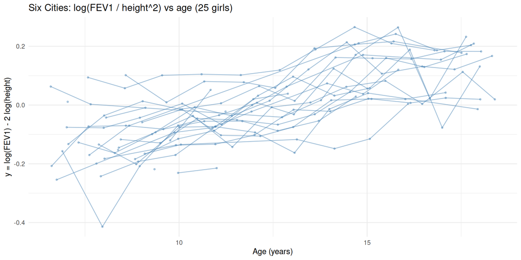

## Fit FE and RE on Six Cities

```r
# RE = the Chapter 8 random-intercept mixed model (PROC MIXED in FLW)
re <- lme(y ~ age, random = ~ 1 | id, data = fev, method = "REML")

# FE = OLS with a subject indicator (dummy) per subject; within estimator.
# Regressing on within-centered age + subject dummies gives the within slope
# (PROC GLM with CLASS/ABSORB id in FLW Section 9.7).
fe <- lm(y ~ age_w + factor(id), data = fev)

data.frame(
  model       = c("RE (mixed model, lme)", "FE (OLS + subject dummies)"),
  age_slope   = c(fixef(re)["age"], coef(fe)["age_w"])
)
```

**Reading it**

Both slopes are **0.0298** (about 3% per year increase in height-adjusted lung function). FE = RE: this is FLW’s **congruent** case. The subject effect appears uncorrelated with age, so the mixed model and the dummy-variable fit agree.

## Fit FE and RE on Six Cities

```
                           model  age_slope
age        RE (mixed model, lme) 0.02984875
age_w FE (OLS + subject dummies) 0.02982264
```

## Six Cities: FLW’s SAS Output (static)

FLW Section 9.6-9.7 fits the same models in SAS. The age effect is identical across approaches:

```sas
/* RE: random-intercept mixed model (FLW Section 9.6) */
PROC MIXED DATA=fev1 METHOD=REML;
  CLASS id;
  MODEL y = age / SOLUTION;
  RANDOM INTERCEPT / SUBJECT=id;
RUN;
/* age effect ~ 0.0298 */

/* FE: OLS with subject indicators (FLW Section 9.7) */
PROC GLM DATA=fev1;
  ABSORB id;
  MODEL y = age / SOLUTION;
RUN;
/* within age effect ~ 0.0298  (congruent with RE) */
```

**Tip**

Same numbers, two idioms: a mixed model (`PROC MIXED` / `lme`) and dummy-variable OLS (`PROC GLM ABSORB` / `lm(... + factor(id))`).

# Part 3: FLW’s Centerpiece, the Decomposition

## Between/Within Decomposition (FLW eq. 9.5)

Rather than choose FE **or** RE, FLW recommends fitting **one richer mixed model** that splits the covariate into its between and within parts:

$$Y_{ij} = \beta^{(C)}\,\bar X_i \;+\; \beta^{(L)}\,(X_{ij} - \bar X_i) \;+\; \alpha_i + \varepsilon_{ij}$$

| Coefficient | Name | Interpretation |
| --- | --- | --- |
| $\beta^{(C)}$ | between / cross-sectional | how subjects with different **average** $X$ differ |
| $\beta^{(L)}$ | within / longitudinal | how $Y$ changes as $X$ changes **within** a subject |

**Tip**

FLW frames this combined model as **more attractive** than the binary FE-vs-RE choice: it reports both effects and contains the adjudication test inside it.

## The Adjudication Test: $H_0:\ \beta^{(C)} = \beta^{(L)}$

The RE (mixed) model assumes the between and within effects are the **same** $\beta$. So the assumption $\operatorname{Cov}(\alpha_i, X_{ij}) = 0$ is equivalent to:

$$H_0:\ \beta^{(C)} = \beta^{(L)}$$

- **Fail to reject:** between and within agree, so RE is valid (and more efficient). Use RE. *(Congruent.)*
- **Reject:** the effects differ, so the pooled RE estimate is a misleading blend. Report $\beta^{(L)}$ (within, FE-like) and $\beta^{(C)}$ (between) separately.

**Note**

A convenient equivalent fit: regress on $X_{ij}$ **and** $\bar X_i$. The coefficient on $\bar X_i$ is the **contextual** effect $\beta^{(C)} - \beta^{(L)}$, and testing it equals zero is the same test.

## Decomposition on Six Cities

```r
# FLW eq. 9.5: between (age_bar) + within (age_w) effects in one mixed model
dec <- lme(y ~ age_w + age_bar, random = ~ 1 | id, data = fev, method = "REML")

data.frame(
  effect      = c("within  beta^(L)  (age_w)", "between beta^(C)  (age_bar)"),
  estimate    = c(fixef(dec)["age_w"], fixef(dec)["age_bar"])
)
```

**Reading it**

$\beta^{(L)} = 0.0298$ (within) and $\beta^{(C)} = 0.031$ (between) are very close. Their near-equality is the visual signal that FE and RE will agree.

## Decomposition on Six Cities

```
                             effect   estimate
age_w     within  beta^(L)  (age_w) 0.02982264
age_bar between beta^(C)  (age_bar) 0.03096632
```

## Test $\beta^{(C)} = \beta^{(L)}$ via the Contextual Coefficient

```r
# Equivalent fit: x and x-bar. The age_bar coefficient is the CONTEXTUAL effect
# beta^(C) - beta^(L); testing it = 0 tests H0: beta^(C) = beta^(L).
dec2 <- lme(y ~ age + age_bar, random = ~ 1 | id, data = fev, method = "ML")
round(summary(dec2)$tTable["age_bar", ], 4)
```

**Reading it**

The contextual coefficient is $\approx 0.001$ with **p $\approx$ 0.72**: we **fail to reject** $H_0:\ \beta^{(C)} = \beta^{(L)}$. We reach the same **congruent** conclusion as FLW’s case study (FLW report a chi-square of 0.04 on 1 df, $p > 0.80$; our fit on these data gives $p \approx 0.72$). Both clearly fail to reject. The between and within age effects are statistically indistinguishable, so the RE mixed model is appropriate and we report the single age effect of about 3% per year.

## Test $\beta^{(C)} = \beta^{(L)}$ via the Contextual Coefficient

```
    Value Std.Error        DF   t-value   p-value
   0.0011    0.0032  298.0000    0.3595    0.7195
```

## Check Your Understanding: Decomposition

**Pause and Reflect**

1. In FLW’s decomposition (eq. 9.5), what do $\beta^{(L)}$ and $\beta^{(C)}$ represent?
2. Why is testing $H_0:\ \beta^{(C)} = \beta^{(L)}$ the right way to decide between FE and RE?
3. In the Six Cities analysis, we failed to reject. What do we report, and why?

**Answers:** (1) $\beta^{(L)}$ is the **within-subject (longitudinal)** effect (change over time within a girl); $\beta^{(C)}$ is the **between-subject (cross-sectional)** effect (differences across girls with different mean age). (2) The RE mixed model assumes one common $\beta$ for both sources, which holds exactly when $\beta^{(C)} = \beta^{(L)}$, i.e. when $\operatorname{Cov}(\alpha_i, X_{ij})=0$. (3) We report the single RE age effect ($\approx 0.0298$, 3%/yr) from the more efficient mixed model, because between and within agree (congruent).

# Part 4: Choosing and Reporting

## FLW’s Recommended Workflow

1. Fit the **RE mixed model** (Ch. 8 random intercept). This is your default.
2. Fit the **decomposition model** (eq. 9.5): split each subject-varying covariate into $\bar X_i$ (between) and $X_{ij}-\bar X_i$ (within).
3. **Test** $\beta^{(C)} = \beta^{(L)}$ (the contextual coefficient).
4. **If congruent:** report the parsimonious RE effect. **If not:** report $\beta^{(L)}$ (within) and $\beta^{(C)}$ (between) separately, and note that a single pooled effect would be misleading.

**Tip**

The decomposition model is strictly more informative than a binary FE/RE choice: it gives you the test **and** both effects in one fit.

## FE vs RE: What Each Buys You

| Model | Treats $\alpha_i$ as | Strength | Cost |
| --- | --- | --- | --- |
| **FE** (dummies / within) | fixed | Consistent even if $\operatorname{Cov}(\alpha_i,X)\neq 0$; sweeps out all time-invariant confounding | Cannot estimate time-invariant covariates $W_i$; less efficient |
| **RE** (Ch. 8 mixed) | random | Efficient; estimates $W_i$; gives subject-level predictions (BLUPs) | Biased if $\operatorname{Cov}(\alpha_i,X)\neq 0$ |
| **Decomposition** (eq. 9.5) | random | Reports both $\beta^{(C)}$ and $\beta^{(L)}$; contains the test | One extra term per covariate |

## Common Mistakes to Avoid

**Critical Errors Students Make**

| Mistake | Why It Is Wrong | Correct Approach |
| --- | --- | --- |
| Treating “RE” as a new estimator | In Ch. 9 the RE model **is** the Ch. 8 random-intercept mixed model | Fit it with `lme`/`lmer` as before |
| Interpreting the FE slope as an “overall effect” | FE estimates the **within-subject** effect only | State it as the within effect $\beta^{(L)}$ |
| Assuming FE removes all confounding | FE removes only **time-invariant** confounding | Adjust time-varying confounders explicitly |
| Putting subject **means of $Y$** in the decomposition | Creates a feedback problem; decompose **covariates** ($\bar X_i$), not the outcome | Use $\bar X_i$ and $X_{ij}-\bar X_i$ |
| Confusing Ch. 8 and Ch. 9 “random effects” | Same term, the biostatistics one is the random intercept | See the terminology callout at the start |

## Key Takeaways

| Item | Key Property |
| --- | --- |
| **FE** | OLS with subject dummies (eq. 9.1); within estimator; robust to time-invariant confounding |
| **RE** | The Ch. 8 random-intercept mixed model; efficient if $\operatorname{Cov}(\alpha_i,X)=0$ |
| **Decomposition (eq. 9.5)** | FLW’s centerpiece: $\beta^{(C)}$ (between) + $\beta^{(L)}$ (within) in one mixed model |
| **Adjudication** | Test $H_0:\ \beta^{(C)}=\beta^{(L)}$; Six Cities is congruent (FE = RE = 0.0298; contextual test non-significant, $p \approx 0.72$) |

# Beyond FLW: The Econometrics Idiom

**This section is supplementary**

Panel-data econometrics teaches the **same** FE/RE ideas in a different vocabulary, with the `plm` package (Croissant & Millo 2008, *J. Stat. Softw.*). FLW does **not** present Ch. 9 this way; the Hausman test gets a single parenthetical sentence in FLW Section 9.4. We include it so you can read the econometrics literature, but the **primary** method for this course is FLW’s decomposition test above.

**Translation:** “endogeneity” = $\operatorname{Cov}(\alpha_i,X)\neq 0$. “Swamy-Arora RE” = the GLS estimator for the random-intercept model. “Hausman test” = the econometrics analogue of FLW’s $\beta^{(C)}=\beta^{(L)}$ test. “Mundlak / correlated RE” = FLW’s decomposition model (eq. 9.5).

## `plm`: FE and RE the Econometrics Way

```r
have_plm <- requireNamespace("plm", quietly = TRUE)
if (have_plm) suppressMessages(library(plm))
if (requireNamespace("lmtest", quietly = TRUE)) suppressMessages(library(lmtest))
if (requireNamespace("sandwich", quietly = TRUE)) suppressMessages(library(sandwich))

if (have_plm) {
  fe_p <- plm(y ~ age, data = fev, index = "id", model = "within")
  re_p <- plm(y ~ age, data = fev, index = "id",
              model = "random", random.method = "swar")  # Swamy-Arora
  print(data.frame(
    model     = c("FE (plm within)", "RE (plm Swamy-Arora)"),
    age_slope = c(coef(fe_p)["age"], coef(re_p)["age"])
  ))
} else {
  message("plm not installed; skipping econometrics supplement.")
}
```

**Reading it**

`plm` reproduces the same age slope ($\approx 0.0298$) we got from `lm(... + factor(id))` and `lme()`. The within / Swamy-Arora estimators are the econometrics names for FE and RE.

## `plm`: FE and RE the Econometrics Way

```
                 model  age_slope
1      FE (plm within) 0.02982264
2 RE (plm Swamy-Arora) 0.02985287
```

## The Hausman Test (econometrics analogue)

The Hausman test (Hausman 1978, *Econometrica*) compares the FE and RE coefficient vectors. It is the econometrics analogue of FLW’s $\beta^{(C)} = \beta^{(L)}$ test, **not** the method FLW teaches.

```r
if (have_plm) {
  print(phtest(fe_p, re_p))
}
```

**Reading it**

Fail to reject (p large): no evidence that FE and RE disagree, the same congruent conclusion as the $\beta^{(C)}=\beta^{(L)}$ test. **Caveat:** `phtest()` requires two `plm` objects (do not pass an `lme` fit); the classical version assumes homoskedasticity.

## The Hausman Test (econometrics analogue)

```
    Hausman Test

data:  y ~ age
chisq = 1.0657, df = 1, p-value = 0.3019
alternative hypothesis: one model is inconsistent
```

## Robust Hausman and Two-Way FE

```r
if (have_plm && requireNamespace("sandwich", quietly = TRUE)) {
  # Robust (clustered) Hausman, for heteroskedasticity / serial correlation
  print(phtest(fe_p, re_p,
        vcov = function(z) vcovHC(z, method = "arellano", type = "HC0", cluster = "group")))

  # Two-way FE: also absorb common time shocks (here, rounded age groups)
  fev$age_grp <- factor(round(fev$age))
  fe_tw <- plm(y ~ age, data = fev, index = c("id", "age_grp"),
               model = "within", effect = "twoways")
  cat("Two-way FE age slope:", round(coef(fe_tw)["age"], 4), "\n")
}
```

**Tip**

Robust SEs (`vcovHC`, Croissant & Millo 2008) and two-way FE are econometrics conveniences. The biostatistics route to the same robustness is the decomposition model plus a mixed-model covariance structure (Ch. 7-8).

## Robust Hausman and Two-Way FE

```
    Hausman Test

data:  y ~ age
chisq = 1.0657, df = 1, p-value = 0.3019
alternative hypothesis: one model is inconsistent
```

```
Two-way FE age slope: 0.0339
```

## Supplement: The Endogeneity Mechanism (simulation)

To **see** what makes FE and RE disagree, simulate a covariate correlated with $\alpha_i$. This illustrates the mechanism; it is not from FLW.

```r
gen_panel <- function(n = 100, T = 6, beta = 1, rho_xa = 0) {
  alpha <- rnorm(n, 0, 1)
  data.frame(id = rep(1:n, each = T)) |>
    mutate(a = rep(alpha, each = T),
           x = rnorm(n * T, 0, 1) + rho_xa * a,   # rho_xa > 0: x correlated with alpha
           y = 2 + beta * x + a + rnorm(n * T, 0, 1))
}
set.seed(667)
fit_both <- function(rho) {
  d <- gen_panel(rho_xa = rho)
  d <- d |> group_by(id) |> mutate(xb = mean(x), xw = x - xb) |> ungroup()
  c(FE_within = coef(lm(y ~ xw + factor(id), data = d))["xw"],
    RE_mixed  = fixef(lme(y ~ x, random = ~ 1 | id, data = d))["x"])
}
rbind(`Scenario A: rho_xa = 0 (congruent)` = round(fit_both(0), 3),
      `Scenario B: rho_xa = 0.5 (RE biased)` = round(fit_both(0.5), 3))
```

**Reading it**

Scenario A ($\operatorname{Cov}(\alpha_i,X)=0$): FE $\approx$ RE $\approx$ true $\beta=1$. Scenario B ($\operatorname{Cov}(\alpha_i,X)>0$): RE is pulled **above** 1 while FE stays near 1. This bias is exactly what the $\beta^{(C)}=\beta^{(L)}$ test (or its Hausman analogue) detects.

## Supplement: The Endogeneity Mechanism (simulation)

```
                                     FE_within.xw RE_mixed.x
Scenario A: rho_xa = 0 (congruent)          0.923      0.917
Scenario B: rho_xa = 0.5 (RE biased)        0.993      1.075
```

## References (supplement)

- Fitzmaurice, Laird & Ware (2011), *Applied Longitudinal Data Analysis*, Ch. 9 (Sections 9.4, 9.6-9.8) and eq. (9.1), (9.5).
- Croissant, Y. & Millo, G. (2008). Panel Data Econometrics in R: The `plm` Package. *Journal of Statistical Software*, 27(2).
- Hausman, J. A. (1978). Specification Tests in Econometrics. *Econometrica*, 46(6), 1251-1271.
- Mundlak, Y. (1978). On the Pooling of Time Series and Cross Section Data. *Econometrica*, 46(1), 69-85.